# I ) Data preparation & exploration:

#### Check for each column if it has outliers

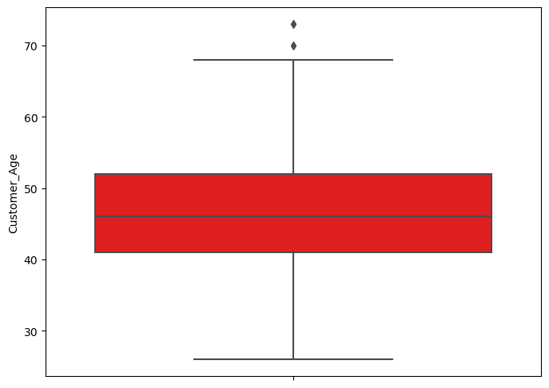

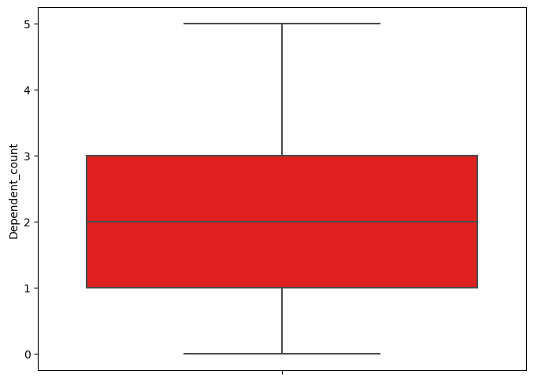

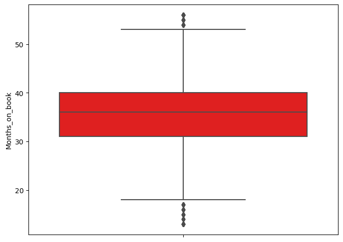

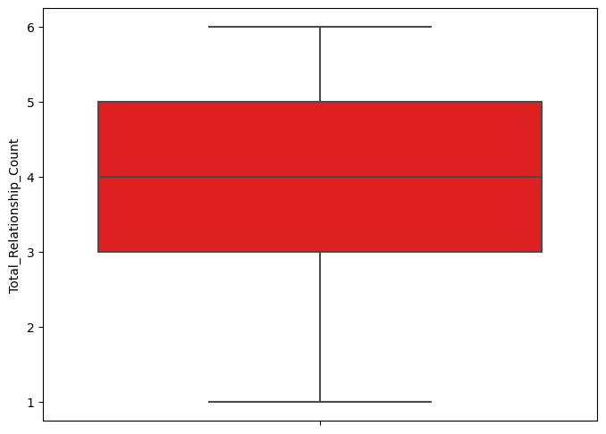

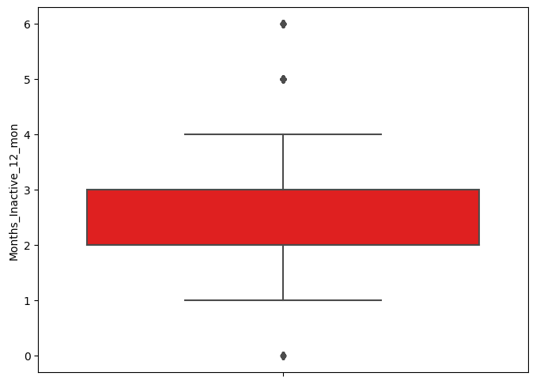

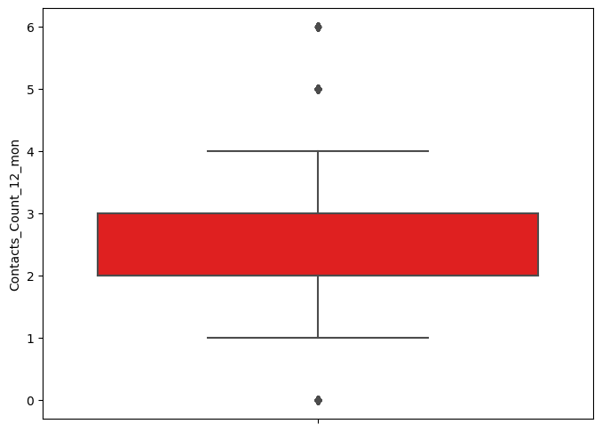

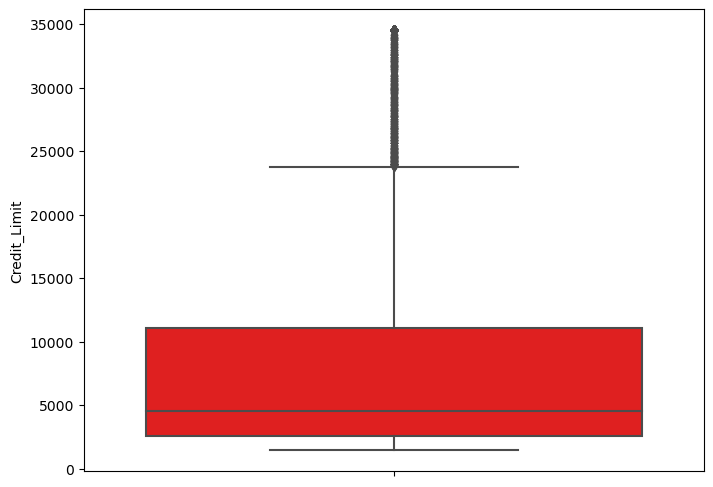

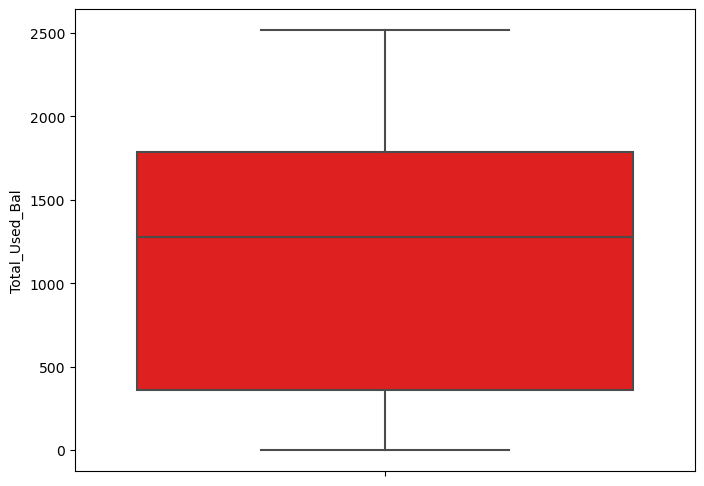

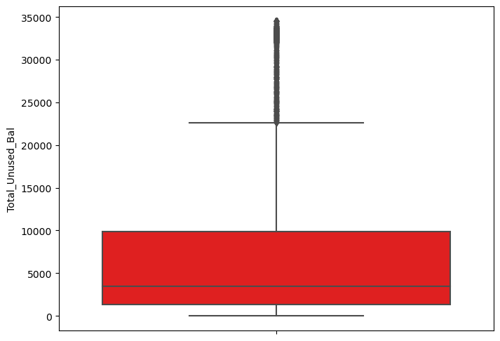

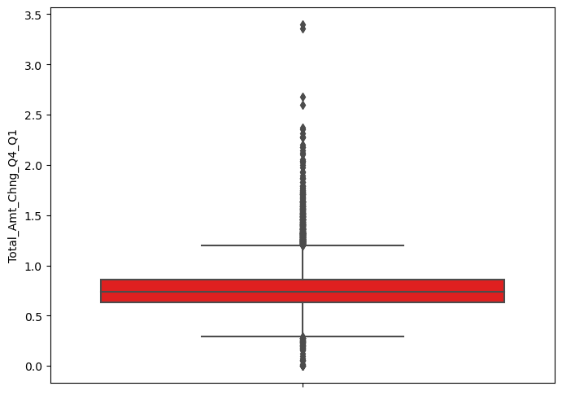

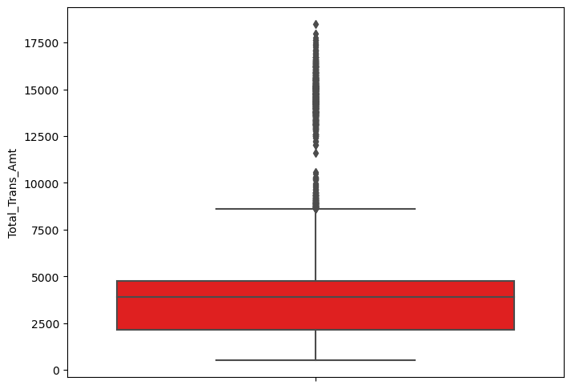

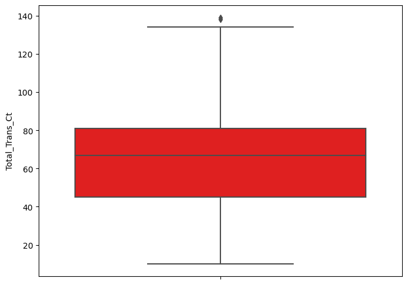

[2 more figures not shown]

```python
for col in numerical_columns:
    fig, ax = plt.subplots(figsize = (8,6))
    sns.boxplot(y = data[col], color = 'red')
    plt.show()
```

```python
heavy_affected_by_outliers = ['Credit_Limit', 'Total_Unused_Bal', 'Total_Amt_Chng_Q4_Q1', 'Total_Trans_Amt', 'Total_Ct_Chng_Q4_Q1']
```

```python
def censoring_outliers(dataframe, column):
    q1 = dataframe[column].quantile(0.25)
    q3 = dataframe[column].quantile(0.75)
    IQR = q3 - q1
    lower_limit = q1 - 3 * IQR
    upper_limit = q3 + 3 * IQR
    dataframe[column] = np.where(dataframe[column] < lower_limit, lower_limit, np.where(dataframe[column] > upper_limit, upper_limit, dataframe[column]))
```

```python
for variable in heavy_affected_by_outliers:
    censoring_outliers(data, variable)
```

e) Correlation

```python
correlation = data[numerical_columns].corr()
correlation
```

|  | Customer_Age | Dependent_count | Months_on_book | Total_Relationship_Count | Months_Inactive_12_mon | Contacts_Count_12_mon | Credit_Limit | Total_Used_Bal | Total_Unused_Bal | Total_Amt_Chng_Q4_Q1 | Total_Trans_Amt | Total_Trans_Ct | Total_Ct_Chng_Q4_Q1 | Avg_Utilization_Ratio |
| --- | --- | --- | --- | --- | --- | --- | --- | --- | --- | --- | --- | --- | --- | --- |
| Customer_Age | 1.000000 | -0.122398 | 0.788891 | -0.010931 | 0.054325 | -0.018452 | 0.002556 | 0.014729 | 0.001234 | -0.068957 | -0.046037 | -0.067088 | -0.018825 | 0.007022 |
| Dependent_count | -0.122398 | 1.000000 | -0.103357 | -0.039238 | -0.011519 | -0.040601 | 0.068197 | -0.002753 | 0.068430 | -0.036400 | 0.032839 | 0.050815 | 0.011219 | -0.037095 |
| Months_on_book | 0.788891 | -0.103357 | 1.000000 | -0.009203 | 0.074164 | -0.010774 | 0.007507 | 0.008623 | 0.006732 | -0.055050 | -0.037315 | -0.049819 | -0.018958 | -0.007541 |
| Total_Relationship_Count | -0.010931 | -0.039238 | -0.009203 | 1.000000 | -0.003675 | 0.055203 | -0.071386 | 0.013726 | -0.072601 | 0.049542 | -0.359299 | -0.241891 | 0.041464 | 0.067663 |
| Months_Inactive_12_mon | 0.054325 | -0.011519 | 0.074164 | -0.003675 | 1.000000 | 0.029493 | -0.020394 | -0.042210 | -0.016605 | -0.032146 | -0.036493 | -0.042787 | -0.043911 | -0.007503 |
| Contacts_Count_12_mon | -0.018452 | -0.040601 | -0.010774 | 0.055203 | 0.029493 | 1.000000 | 0.020817 | -0.053913 | 0.025646 | -0.019470 | -0.122814 | -0.152213 | -0.098280 | -0.055471 |
| Credit_Limit | 0.002556 | 0.068197 | 0.007507 | -0.071386 | -0.020394 | 0.020817 | 1.000000 | 0.042493 | 0.995981 | 0.012631 | 0.169344 | 0.075927 | -0.006200 | -0.482965 |
| Total_Used_Bal | 0.014729 | -0.002753 | 0.008623 | 0.013726 | -0.042210 | -0.053913 | 0.042493 | 1.000000 | -0.047167 | 0.057863 | 0.059969 | 0.056060 | 0.095009 | 0.624022 |
| Total_Unused_Bal | 0.001234 | 0.068430 | 0.006732 | -0.072601 | -0.016605 | 0.025646 | 0.995981 | -0.047167 | 1.000000 | 0.007441 | 0.163932 | 0.070885 | -0.014717 | -0.538808 |
| Total_Amt_Chng_Q4_Q1 | -0.068957 | -0.036400 | -0.055050 | 0.049542 | -0.032146 | -0.019470 | 0.012631 | 0.057863 | 0.007441 | 1.000000 | 0.055264 | 0.024123 | 0.366869 | 0.036923 |
| Total_Trans_Amt | -0.046037 | 0.032839 | -0.037315 | -0.359299 | -0.036493 | -0.122814 | 0.169344 | 0.059969 | 0.163932 | 0.055264 | 1.000000 | 0.832520 | 0.117409 | -0.078081 |
| Total_Trans_Ct | -0.067088 | 0.050815 | -0.049819 | -0.241891 | -0.042787 | -0.152213 | 0.075927 | 0.056060 | 0.070885 | 0.024123 | 0.832520 | 1.000000 | 0.152392 | 0.002838 |
| Total_Ct_Chng_Q4_Q1 | -0.018825 | 0.011219 | -0.018958 | 0.041464 | -0.043911 | -0.098280 | -0.006200 | 0.095009 | -0.014717 | 0.366869 | 0.117409 | 0.152392 | 1.000000 | 0.080625 |
| Avg_Utilization_Ratio | 0.007022 | -0.037095 | -0.007541 | 0.067663 | -0.007503 | -0.055471 | -0.482965 | 0.624022 | -0.538808 | 0.036923 | -0.078081 | 0.002838 | 0.080625 | 1.000000 |

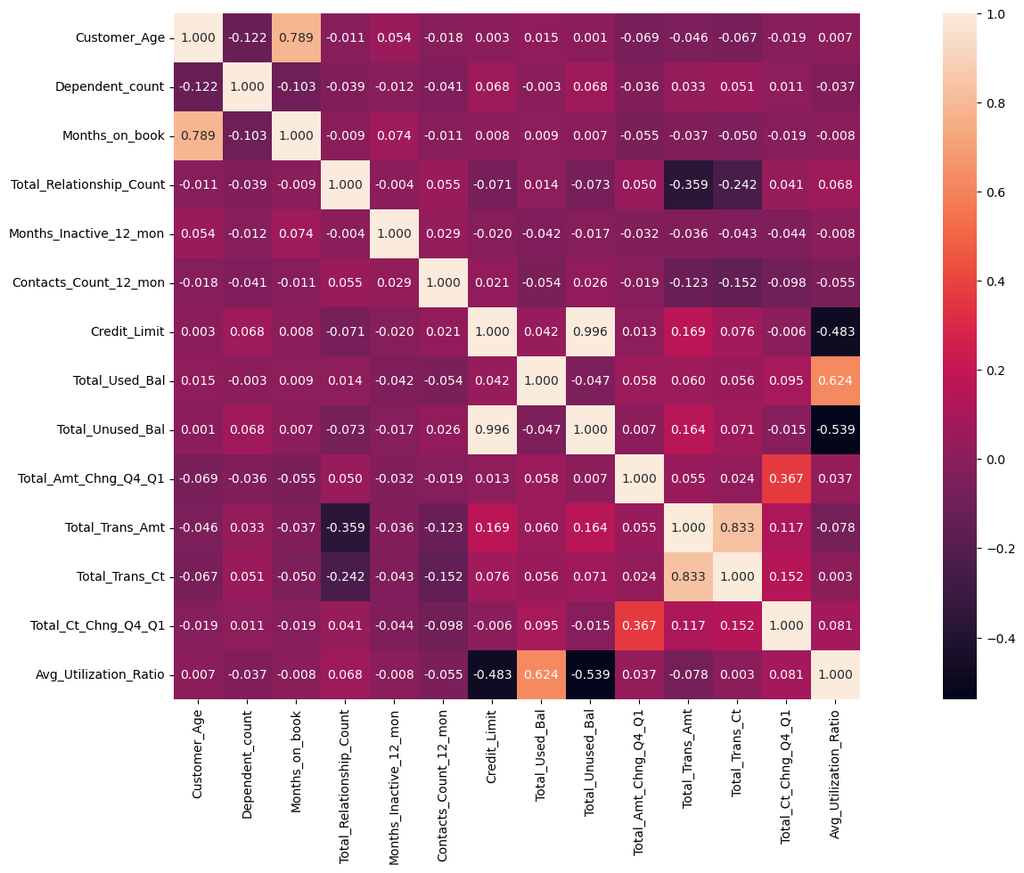

```python
fig, ax = plt.subplots(figsize = (24,10))
sns.heatmap(correlation, annot = True, square = True, fmt = '.3f')
plt.show()
```

```python
columns_to_drop = ['Months_on_book']
columns_to_drop.append('Total_Unused_Bal')
columns_to_drop.append('Total_Trans_Ct')

numerical_columns.remove('Months_on_book')
numerical_columns.remove('Total_Unused_Bal')
numerical_columns.remove('Total_Trans_Ct')
```

# E. Final dataset

```python
print(columns_to_drop)
```

```
['Months_on_book', 'Total_Unused_Bal', 'Total_Trans_Ct']
```

```python
data = data.drop(columns = columns_to_drop)
```

```python
data.to_csv('C:\\Users\\teodo\\Desktop\\BCR\\TTJ project\\Transformed_Dataset.csv')
```

# II ) Model development:

# A. Import libraries

```python
import numpy as np
import pandas as pd
import matplotlib.pyplot as plt
import seaborn as sns
from sklearn.model_selection import train_test_split
from sklearn.ensemble import RandomForestClassifier
from xgboost import XGBClassifier
from sklearn.metrics import accuracy_score,precision_score,recall_score,roc_auc_score,confusion_matrix,roc_curve
```

# B. Read dataset

```python
data = pd.read_csv('C:\\Users\\teodo\\Desktop\\BCR\\TTJ project\\Transformed_Dataset.csv', index_col = 'Unnamed: 0')
```

```python
data.head()
```

|  | CLIENTNUM | Attrition_Flag | Customer_Age | Gender | Dependent_count | Education_Level | Marital_Status | Income_Category | Card_Category | Total_Relationship_Count | Months_Inactive_12_mon | Contacts_Count_12_mon | Credit_Limit | Total_Used_Bal | Total_Amt_Chng_Q4_Q1 | Total_Trans_Amt | Total_Ct_Chng_Q4_Q1 | Avg_Utilization_Ratio |
| --- | --- | --- | --- | --- | --- | --- | --- | --- | --- | --- | --- | --- | --- | --- | --- | --- | --- | --- |
| 0 | 768805383 | 0 | 45.0 | M | 3.0 | High School | Married | $60K - $80K | Blue | 5 | 1 | 3 | 12691.0 | 777 | 1.335 | 1144.0 | 1.526 | 0.061 |
| 1 | 818770008 | 0 | 49.0 | F | 5.0 | Graduate | Single | Less than $40K | Blue | 6 | 1 | 2 | 8256.0 | 864 | 1.541 | 1291.0 | 1.526 | 0.105 |
| 2 | 713982108 | 0 | 51.0 | M | 3.0 | Graduate | Married | $80K - $120K | Blue | 4 | 1 | 0 | 3418.0 | 0 | 1.543 | 1887.0 | 1.526 | 0.000 |
| 3 | 769911858 | 0 | 40.0 | F | 4.0 | High School | Other status | Less than $40K | Blue | 3 | 4 | 1 | 3313.0 | 2517 | 1.405 | 1171.0 | 1.526 | 0.760 |
| 4 | 709106358 | 0 | 40.0 | M | 3.0 | Uneducated | Married | $60K - $80K | Blue | 5 | 1 | 0 | 4716.0 | 0 | 1.543 | 816.0 | 1.526 | 0.000 |

# C. Classification

## 1. Declare independent variables and target variable

```python
# independent variables

X = data.drop(columns = ['Attrition_Flag'])

# target variable

y = data['Attrition_Flag']
```

```python
X.shape, y.shape
```

```
((10127, 17), (10127,))
```

```python
X.head()
```

|  | CLIENTNUM | Customer_Age | Gender | Dependent_count | Education_Level | Marital_Status | Income_Category | Card_Category | Total_Relationship_Count | Months_Inactive_12_mon | Contacts_Count_12_mon | Credit_Limit | Total_Used_Bal | Total_Amt_Chng_Q4_Q1 | Total_Trans_Amt | Total_Ct_Chng_Q4_Q1 | Avg_Utilization_Ratio |
| --- | --- | --- | --- | --- | --- | --- | --- | --- | --- | --- | --- | --- | --- | --- | --- | --- | --- |
| 0 | 768805383 | 45.0 | M | 3.0 | High School | Married | $60K - $80K | Blue | 5 | 1 | 3 | 12691.0 | 777 | 1.335 | 1144.0 | 1.526 | 0.061 |
| 1 | 818770008 | 49.0 | F | 5.0 | Graduate | Single | Less than $40K | Blue | 6 | 1 | 2 | 8256.0 | 864 | 1.541 | 1291.0 | 1.526 | 0.105 |
| 2 | 713982108 | 51.0 | M | 3.0 | Graduate | Married | $80K - $120K | Blue | 4 | 1 | 0 | 3418.0 | 0 | 1.543 | 1887.0 | 1.526 | 0.000 |
| 3 | 769911858 | 40.0 | F | 4.0 | High School | Other status | Less than $40K | Blue | 3 | 4 | 1 | 3313.0 | 2517 | 1.405 | 1171.0 | 1.526 | 0.760 |
| 4 | 709106358 | 40.0 | M | 3.0 | Uneducated | Married | $60K - $80K | Blue | 5 | 1 | 0 | 4716.0 | 0 | 1.543 | 816.0 | 1.526 | 0.000 |

## 2. Perform data preprocessing

a) Check variables 'Marital_Status' and 'Card_Category'

```python
X['Marital_Status'].unique()
```

```
array(['Married', 'Single', 'Other status'], dtype=object)
```

```python
X['Card_Category'].unique()
```

```
array(['Blue', 'Silver / Gold / Platinum'], dtype=object)
```

```python
X = X.drop(columns = ['CLIENTNUM', 'Marital_Status','Card_Category'])
```

b) Categorical encoding

```python
categorical_columns = [col for col in X.columns if X[col].dtypes == 'object']
```

```python
categorical_columns
```

```
['Gender', 'Education_Level', 'Income_Category']
```

```python
X = pd.get_dummies(X, columns = categorical_columns)
```

```python
X.head()
```

|  | Customer_Age | Dependent_count | Total_Relationship_Count | Months_Inactive_12_mon | Contacts_Count_12_mon | Credit_Limit | Total_Used_Bal | Total_Amt_Chng_Q4_Q1 | Total_Trans_Amt | Total_Ct_Chng_Q4_Q1 | ... | Education_Level_High School | Education_Level_Post-Graduate / Doctorate | Education_Level_Uneducated | Education_Level_Unknown | Income_Category_$120K + | Income_Category_$40K - $60K | Income_Category_$60K - $80K | Income_Category_$80K - $120K | Income_Category_Less than $40K | Income_Category_Unknown |
| --- | --- | --- | --- | --- | --- | --- | --- | --- | --- | --- | --- | --- | --- | --- | --- | --- | --- | --- | --- | --- | --- |
| 0 | 45.0 | 3.0 | 5 | 1 | 3 | 12691.0 | 777 | 1.335 | 1144.0 | 1.526 | ... | 1 | 0 | 0 | 0 | 0 | 0 | 1 | 0 | 0 | 0 |
| 1 | 49.0 | 5.0 | 6 | 1 | 2 | 8256.0 | 864 | 1.541 | 1291.0 | 1.526 | ... | 0 | 0 | 0 | 0 | 0 | 0 | 0 | 0 | 1 | 0 |
| 2 | 51.0 | 3.0 | 4 | 1 | 0 | 3418.0 | 0 | 1.543 | 1887.0 | 1.526 | ... | 0 | 0 | 0 | 0 | 0 | 0 | 0 | 1 | 0 | 0 |
| 3 | 40.0 | 4.0 | 3 | 4 | 1 | 3313.0 | 2517 | 1.405 | 1171.0 | 1.526 | ... | 1 | 0 | 0 | 0 | 0 | 0 | 0 | 0 | 1 | 0 |
| 4 | 40.0 | 3.0 | 5 | 1 | 0 | 4716.0 | 0 | 1.543 | 816.0 | 1.526 | ... | 0 | 0 | 1 | 0 | 0 | 0 | 1 | 0 | 0 | 0 |

5 rows × 25 columns

## 3. Split train and test sets

```python
X_train, X_test, y_train, y_test = train_test_split(X,y,test_size = 0.2,random_state = 10)
```

```python
X_train.shape, X_test.shape, y_train.shape, y_test.shape
```

```
((8101, 25), (2026, 25), (8101,), (2026,))
```

## 4. Random Forest

### 4.1 Train algorithm

- Instatiate algorithm

```python
rf = RandomForestClassifier(n_estimators = 300,max_depth = 5,n_jobs = -1, random_state = 123)
```

- Train algorithm

```python
rf.fit(X_train,y_train)
```

```
RandomForestClassifier(max_depth=5, n_estimators=300, n_jobs=-1,
                       random_state=123)
```

### 4.2 Predict results

```python
y_predict = rf.predict(X_test)
```

```python
y_predict
```

```
array([0, 0, 0, ..., 1, 0, 0], dtype=int64)
```

### 4.3 Performance metrics

a) Accuracy_score

```python
accuracy = accuracy_score(y_test,y_predict)
```

```python
print('Accuracy score for RFC is:',accuracy)
```

```
Accuracy score for RFC is: 0.9081934846989141
```

#### Comment: Very good accuracy!

b) Confusion matrix

```python
cm = confusion_matrix(y_test,y_predict)
print(cm)
```

```
[[1690   15]
 [ 171  150]]
```

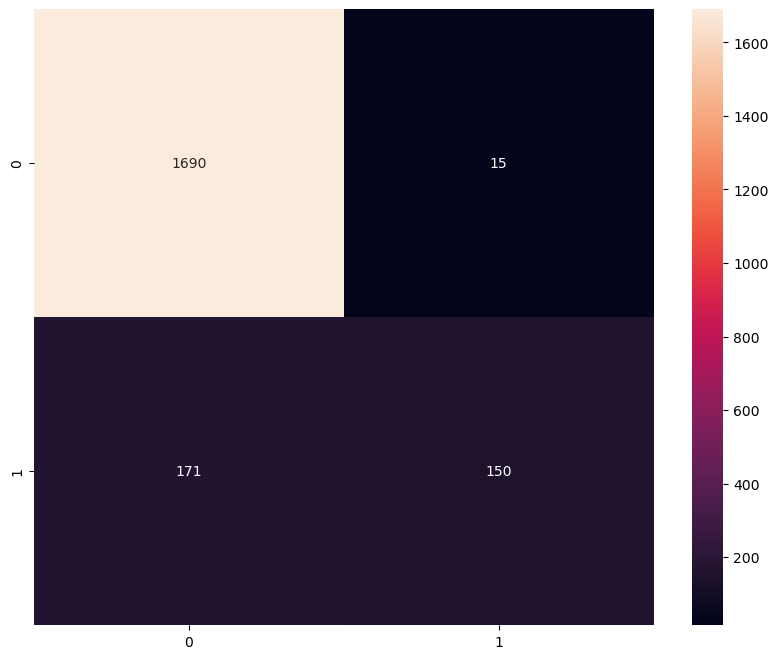

```python
fix, ax = plt.subplots(figsize = (10,8))
sns.heatmap(cm,annot=True,fmt = 'd')
plt.show()
```

#### Comments:

#### 1) 1690 => True Negative ( TN )

#### 2) 15 => False Positive ( FP )

#### 3) 171 => False Negative ( FN )

#### 4) 150 => True Positive ( TP )

c) Precision, recall

```python
precision = precision_score(y_test,y_predict)
recall = recall_score(y_test,y_predict)
print('Precision score:',precision)
print('Recall score:',recall)
```

```
Precision score: 0.9090909090909091
Recall score: 0.4672897196261682
```

#### Comments:

#### 1) Precision score => Out of the positive predicted ones, 90,9% are really positive.

#### 2) Recall score => Of all positive observations, we predicted 46,73% as positive.

- Check for overfitting

```python
y_train_predict = rf.predict(X_train)
```

```python
precision = precision_score(y_train,y_train_predict)
recall = recall_score(y_train,y_train_predict)
print('Precision score:',precision)
print('Recall score:',recall)
```

```
Precision score: 0.9239766081871345
Recall score: 0.48392036753445633
```

d) AUC score

```python
auc_score = roc_auc_score(y_test,y_predict)
print("AUC score is:",auc_score)
```

```
AUC score is: 0.729246032833612
```

#### Comment: Good AUC value.

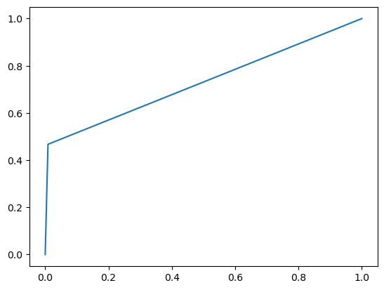

```python
fpr, tpr, threshold = roc_curve(y_test,y_predict)
plt.plot(fpr,tpr)
```

#### Comment: We have a decent classifier.

# We are trying another algorithm ( XGBoost ):

## 5. XGBoost ( Extreme Gradient Boost )

### 5.1 Train algorithm

```python
xgb = XGBClassifier(n_estimators = 200, max_depth = 3, learning_rate = 0.1, n_jobs = -1, random_state = 10)
```

```python
xgb.fit(X_train,y_train)
```

```
XGBClassifier(base_score=None, booster=None, callbacks=None,
              colsample_bylevel=None, colsample_bynode=None,
              colsample_bytree=None, early_stopping_rounds=None,
              enable_categorical=False, eval_metric=None, feature_types=None,
              gamma=None, gpu_id=None, grow_policy=None, importance_type=None,
              interaction_constraints=None, learning_rate=0.1, max_bin=None,
              max_cat_threshold=None, max_cat_to_onehot=None,
              max_delta_step=None, max_depth=3, max_leaves=None,
              min_child_weight=None, missing=nan, monotone_constraints=None,
              n_estimators=200, n_jobs=-1, num_parallel_tree=None,
              predictor=None, random_state=10, ...)
```

### 5.2 Predict results

```python
y_predict = xgb.predict(X_test)
```

### 5.3 Performance metrics

a) Accuracy score

```python
accuracy = accuracy_score(y_test,y_predict)
print('Accuracy for XGB is:',accuracy)
```

```
Accuracy for XGB is: 0.9531095755182626
```

#### Comment: Accuracy is even better now!

b) Confusion matrix

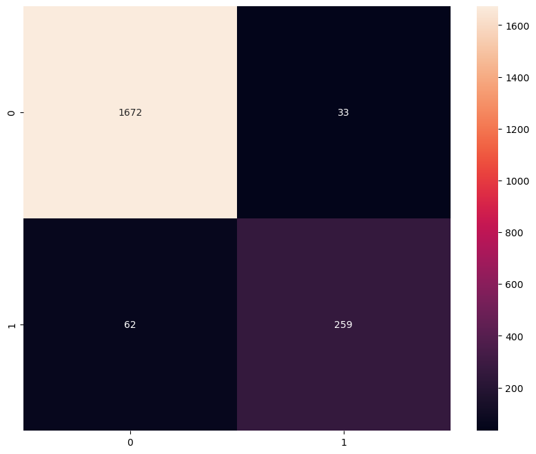

```python
cm = confusion_matrix(y_test,y_predict)
fix,ax = plt.subplots(figsize = (10,8))
sns.heatmap(cm,annot=True,fmt='d')
plt.show()
```

#### Comments:

#### 1) 1672 => True Negative ( TN )

#### 2) 33 => False Positive ( FP )

#### 3) 62 => False Negative ( FN )

#### 4) 259 => True Positive ( TP )

#### Conclusion: This model identifies True Positives better.

c) Precision, recall

```python
precision = precision_score(y_test,y_predict)
recall = recall_score(y_test,y_predict)
print('Precision',precision)
print('Recall',recall)
```

```
Precision 0.886986301369863
Recall 0.8068535825545171
```

#### Comments:

#### 1) Precision score => Out of the positive predicted ones, 88,7% are really positive.

#### 2) Recall score => Of all positive observations, we predicted 80,69% as positive.

d) AUC score

```python
auc_score = roc_auc_score(y_test,y_predict)
print('AUC score is:',auc_score)
```

```
AUC score is: 0.8937493719224198
```

#### Comment: Very good AUC value.

e) Check for overfitting / underfitting

```python
y_predict_train = xgb.predict(X_train)
y_predict_test = xgb.predict(X_test)

auc_score_train = roc_auc_score(y_train,y_predict_train)
auc_score_test = roc_auc_score(y_test,y_predict_test)

print('AUC train:',auc_score_train)
print('AUC test:',auc_score_test)
```

```
AUC train: 0.9367884344289726
AUC test: 0.8937493719224198
```

#### Comment: There is a rather small difference between AUC train and AUC test results => We do not have overfitting / underfitting.

## 6. Hyperparameters tuning

a) Declare possible values for hyperparameters of XGBoost

```python
n_estimators = [200,300]
max_depth = [3,4]
learning_rate = [0.1,0.05]
```

b) Find the best hyperparameters

```python
results = []
for est in n_estimators:
    for md in max_depth:
        for lr in learning_rate:
            xgb = XGBClassifier(n_estimators = est, max_depth = md, learning_rate = lr, n_jobs = -1, random_state = 10)
            xgb.fit(X_train, y_train)
            y_predict = xgb.predict(X_test)
            auc_score = roc_auc_score(y_test, y_predict)
            results.append(['estimator',est,'max_depth',md,'learning_rate',lr,'auc',auc_score])
```

```python
results
```

```
[['estimator',
  200,
  'max_depth',
  3,
  'learning_rate',
  0.1,
  'auc',
  0.8937493719224198],
 ['estimator',
  200,
  'max_depth',
  3,
  'learning_rate',
  0.05,
  'auc',
  0.8690291519353924],
 ['estimator',
  200,
  'max_depth',
  4,
  'learning_rate',
  0.1,
  'auc',
  0.9107919715697828],
 ['estimator',
  200,
  'max_depth',
  4,
  'learning_rate',
  0.05,
  'auc',
  0.8909273622568769],
 ['estimator',
  300,
  'max_depth',
  3,
  'learning_rate',
  0.1,
  'auc',
  0.9070901965083454],
```

[output cut: 9 more lines]

```
  300,
  'max_depth',
  4,
  'learning_rate',
  0.1,
  'auc',
  0.9123496039685366],
 ['estimator',
  300,
  'max_depth',
  4,
  'learning_rate',
  0.05,
  'auc',
  0.9036816765788729]]
```

#### Comment: Model with parameters n estimators = 300, max_depth = 4, learning_rate = 0.1 is better because of AUC score resulted. ( 0.9123496039685366 )

- Check for overfitting

```python
best_model = XGBClassifier(n_estimators = 300, max_depth = 4, learning_rate = 0.1, n_jobs = -1, subsample = 0.6, colsample_bytree = 0.5, random_state = 123)
best_model.fit(X_train,y_train)
y_predict_train = best_model.predict(X_train)
y_predict_test = best_model.predict(X_test)
auc_score_train = roc_auc_score(y_train,y_predict_train)
auc_score_test = roc_auc_score(y_test,y_predict_test)
print('AUC train:', auc_score_train)
print('AUC test:', auc_score_test)
```

```
AUC train: 0.975896552617849
AUC test: 0.9123496039685366
```

#### Comment: This model is better!

## 7. Save the model

```python
import pickle
with open('C:\\Users\\teodo\\Desktop\\BCR\\TTJ project\\final_model_XGB.pkl','wb') as file:
    pickle.dump(best_model, file)
```

# III ) Model explainability:

# A. Import libraries

```python
import numpy as np
import pandas as pd
import matplotlib.pyplot as plt
import seaborn as sns
from sklearn.model_selection import train_test_split
from sklearn.metrics import roc_auc_score
import shap
import pickle
```

# B. Explainability

## 1. Import saved model

```python
with open('C:\\Users\\teodo\\Desktop\\BCR\\TTJ project\\final_model_XGB.pkl', 'rb') as file:
    model = pickle.load(file)
```

## 2. Train test split

```python
# independent variables
X = data.drop(columns = ['Attrition_Flag'])

# target variable
y = data['Attrition_Flag']
```

- Drop columns 'CLIENTNUM', 'Marital_Status' and 'Card_Category'

```python
X = X.drop(columns = ['CLIENTNUM','Marital_Status','Card_Category'])
```

- Categorical encoding

```python
categorical_columns = [col for col in X.columns if X[col].dtypes == 'object']
X = pd.get_dummies(X, columns = categorical_columns)
```

```python
X.head()
```

|  | Customer_Age | Dependent_count | Total_Relationship_Count | Months_Inactive_12_mon | Contacts_Count_12_mon | Credit_Limit | Total_Used_Bal | Total_Amt_Chng_Q4_Q1 | Total_Trans_Amt | Total_Ct_Chng_Q4_Q1 | ... | Education_Level_High School | Education_Level_Post-Graduate / Doctorate | Education_Level_Uneducated | Education_Level_Unknown | Income_Category_$120K + | Income_Category_$40K - $60K | Income_Category_$60K - $80K | Income_Category_$80K - $120K | Income_Category_Less than $40K | Income_Category_Unknown |
| --- | --- | --- | --- | --- | --- | --- | --- | --- | --- | --- | --- | --- | --- | --- | --- | --- | --- | --- | --- | --- | --- |
| 0 | 45.0 | 3.0 | 5 | 1 | 3 | 12691.0 | 777 | 1.335 | 1144.0 | 1.526 | ... | 1 | 0 | 0 | 0 | 0 | 0 | 1 | 0 | 0 | 0 |
| 1 | 49.0 | 5.0 | 6 | 1 | 2 | 8256.0 | 864 | 1.541 | 1291.0 | 1.526 | ... | 0 | 0 | 0 | 0 | 0 | 0 | 0 | 0 | 1 | 0 |
| 2 | 51.0 | 3.0 | 4 | 1 | 0 | 3418.0 | 0 | 1.543 | 1887.0 | 1.526 | ... | 0 | 0 | 0 | 0 | 0 | 0 | 0 | 1 | 0 | 0 |
| 3 | 40.0 | 4.0 | 3 | 4 | 1 | 3313.0 | 2517 | 1.405 | 1171.0 | 1.526 | ... | 1 | 0 | 0 | 0 | 0 | 0 | 0 | 0 | 1 | 0 |
| 4 | 40.0 | 3.0 | 5 | 1 | 0 | 4716.0 | 0 | 1.543 | 816.0 | 1.526 | ... | 0 | 0 | 1 | 0 | 0 | 0 | 1 | 0 | 0 | 0 |

5 rows × 25 columns

- Train Test Split

```python
X_train, X_test, y_train, y_test = train_test_split(X,y,test_size = 0.2, random_state = 10)
```

```python
X_train.shape, X_test.shape, y_train.shape, y_test.shape
```

```
((8101, 25), (2026, 25), (8101,), (2026,))
```

## 3. Predict

```python
y_predict = model.predict(X_test)
```

```python
y_predict
```

```
array([0, 0, 0, ..., 1, 0, 0])
```

- Predict likelihood of target variable ( propensity probabilities )

```python
y_predict_proba = model.predict_proba(X_test)
```

```python
y_predict_proba
```

```
array([[9.9718869e-01, 2.8112917e-03],
       [9.9593920e-01, 4.0607778e-03],
       [9.8732466e-01, 1.2675370e-02],
       ...,
       [1.0988712e-03, 9.9890113e-01],
       [9.9948144e-01, 5.1853573e-04],
       [9.8809713e-01, 1.1902890e-02]], dtype=float32)
```

- Out of the 2 probabilities, we are interested in probabilities of class 1 ( right values ).

```python
y_predict_proba_class_1 = y_predict_proba[:,1]
```

```python
y_predict_proba_class_1
```

```
array([2.8112917e-03, 4.0607778e-03, 1.2675370e-02, ..., 9.9890113e-01,
       5.1853573e-04, 1.1902890e-02], dtype=float32)
```

## 4. Performance metrics

### 4.1 AUC score for probabilities

```python
auc_score = roc_auc_score(y_test, y_predict_proba_class_1)
print(auc_score)
```

```
0.9855473639012983
```

#### Comment: Excellent AUC value for probabilities in class 1!

### 4.2 Lift and Gain analysis

```python
# Declare an empty DataFrame
lift_gain_report = pd.DataFrame()

# Add y_test in DataFrame
lift_gain_report['y_test'] = y_test

# STEP 1 #
# Add predict probabilities for class 1 in DataFrame
lift_gain_report['Predicted Probabilities'] = y_predict_proba_class_1

# Order probabilities in ascending order
lift_gain_report['Probabilities Rank'] = lift_gain_report['Predicted Probabilities'].rank(method = 'first', ascending = True, pct = True)

# STEP 2 #
# Calculate decile group
lift_gain_report['Decile group'] = np.floor((1 - lift_gain_report['Probabilities Rank']) * 10) + 1

# STEP 3 #
# Group observations by decile
lift_gain_report['Number of observations'] = 1
lift_gain_report = lift_gain_report.groupby(['Decile group']).sum().reset_index()

# Cumulative number of observations
lift_gain_report['Cumulative no. of observations'] = lift_gain_report['Number of observations'].cumsum()

# Cumulative percentaje of observations
lift_gain_report['Cumulative % of no. of observations'] = lift_gain_report['Cumulative no. of observations'] / lift_gain_report['Cumulative no. of observations'].max()

# STEP 4 #
# Calculate number of positives cumulative
lift_gain_report['Cumulative no. of positives'] = lift_gain_report['y_test'].cumsum()

# STEP 5 #
# Calculate cumulative % of positives ( GAIN )
lift_gain_report['Gain'] = lift_gain_report['Cumulative no. of positives'] / lift_gain_report['Cumulative no. of positives'].max()

# STEP 6 #
# Calculate LIFT
lift_gain_report['Lift'] = lift_gain_report['Gain'] / lift_gain_report['Cumulative % of no. of observations']

lift_gain_report
```

|  | Decile group | y_test | Predicted Probabilities | Probabilities Rank | Number of observations | Cumulative no. of observations | Cumulative % of no. of observations | Cumulative no. of positives | Gain | Lift |
| --- | --- | --- | --- | --- | --- | --- | --- | --- | --- | --- |
| 0 | 1.0 | 196 | 196.717941 | 192.880059 | 203 | 203 | 0.100197 | 196 | 0.610592 | 6.093888 |
| 1 | 2.0 | 104 | 100.083824 | 172.539980 | 203 | 406 | 0.200395 | 300 | 0.934579 | 4.663690 |
| 2 | 3.0 | 18 | 12.539496 | 151.500000 | 202 | 608 | 0.300099 | 318 | 0.990654 | 3.301094 |
| 3 | 4.0 | 1 | 3.279937 | 131.960020 | 203 | 811 | 0.400296 | 319 | 0.993769 | 2.482586 |
| 4 | 5.0 | 1 | 1.198860 | 111.119941 | 202 | 1013 | 0.500000 | 320 | 0.996885 | 1.993769 |
| 5 | 6.0 | 1 | 0.611820 | 91.380059 | 203 | 1216 | 0.600197 | 321 | 1.000000 | 1.666118 |
| 6 | 7.0 | 0 | 0.345242 | 71.039980 | 203 | 1419 | 0.700395 | 321 | 1.000000 | 1.427766 |
| 7 | 8.0 | 0 | 0.197960 | 50.500000 | 202 | 1621 | 0.800099 | 321 | 1.000000 | 1.249846 |
| 8 | 9.0 | 0 | 0.101691 | 30.460020 | 203 | 1824 | 0.900296 | 321 | 1.000000 | 1.110746 |
| 9 | 10.0 | 0 | 0.040535 | 10.119941 | 202 | 2026 | 1.000000 | 321 | 1.000000 | 1.000000 |

#### Comments:

#### 1) By targeting top 10% cases with highest probabilities, we can reach 61,06% out of total positives.

#### By targeting cases from first decile, we can reach an efficiency 6,09 times higher comparing with a random selection.

#### 2) By targeting top 20% cases with highest probabilities, we can reach 93,46% out of total positives.

#### By targeting cases from second decile, we can reach an efficiency 4,66 times higher comparing with a random selection.

#### 3) By targeting top 30% cases with highest probabilities, we can reach 99,07% out of total positives.

#### By targeting cases from third decile, we can reach an efficiency 3,3 times higher comparing with a random selection.

#### 4) By targeting top 40% cases with highest probabilities, we can reach 99,38% out of total positives.

#### By targeting cases from fourth decile, we can reach an efficiency 2,48 times higher comparing with a random selection.

#### 5) By targeting top 50% cases with highest probabilities, we can reach 99,69% out of total positives.

#### By targeting cases from fifth decile, we can reach an efficiency 1,99 times higher comparing with a random selection.

#### 6) By targeting top 60%-70%-80%-90%-100% cases with highest probabilities, we can reach 100%% out of total positives.

#### By targeting cases from sixth decile, we can reach an efficiency 1,67 times higher comparing with a random selection.

#### By targeting cases from seventh decile, we can reach an efficiency 1,43 times higher comparing with a random selection.

#### By targeting cases from eighth decile, we can reach an efficiency 1,25 times higher comparing with a random selection.

#### By targeting cases from ninth decile, we can reach an efficiency 1,11 times higher comparing with a random selection.

#### By targeting cases from tenth decile, we can reach the same efficieny comparing with a random selection.

### 4.3 Lift and Gain charts

a) Lift chart

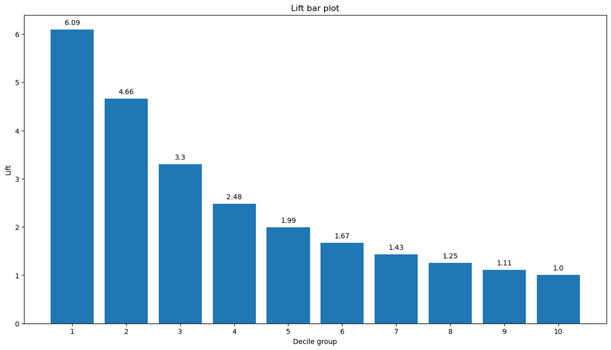

```python
fig, ax = plt.subplots(figsize = (15,8))
barplot = plt.bar(lift_gain_report['Decile group'], lift_gain_report['Lift'])
plt.title('Lift bar plot')
plt.xlabel('Decile group')
plt.ylabel('Lift')
plt.xticks(lift_gain_report['Decile group'])

for b in barplot:
    plt.text(b.get_x() + b.get_width() / 2, b.get_height() + 0.1, round(b.get_height(),2), ha = 'center')

plt.show()
```

b) Gain chart

```python
lift_gain_report['Random Selection'] = lift_gain_report['Decile group'] / lift_gain_report['Decile group'].max()
```

```python
lift_gain_report
```

|  | Decile group | y_test | Predicted Probabilities | Probabilities Rank | Number of observations | Cumulative no. of observations | Cumulative % of no. of observations | Cumulative no. of positives | Gain | Lift | Random Selection |
| --- | --- | --- | --- | --- | --- | --- | --- | --- | --- | --- | --- |
| 0 | 1.0 | 196 | 196.717941 | 192.880059 | 203 | 203 | 0.100197 | 196 | 0.610592 | 6.093888 | 0.1 |
| 1 | 2.0 | 104 | 100.083824 | 172.539980 | 203 | 406 | 0.200395 | 300 | 0.934579 | 4.663690 | 0.2 |
| 2 | 3.0 | 18 | 12.539496 | 151.500000 | 202 | 608 | 0.300099 | 318 | 0.990654 | 3.301094 | 0.3 |
| 3 | 4.0 | 1 | 3.279937 | 131.960020 | 203 | 811 | 0.400296 | 319 | 0.993769 | 2.482586 | 0.4 |
| 4 | 5.0 | 1 | 1.198860 | 111.119941 | 202 | 1013 | 0.500000 | 320 | 0.996885 | 1.993769 | 0.5 |
| 5 | 6.0 | 1 | 0.611820 | 91.380059 | 203 | 1216 | 0.600197 | 321 | 1.000000 | 1.666118 | 0.6 |
| 6 | 7.0 | 0 | 0.345242 | 71.039980 | 203 | 1419 | 0.700395 | 321 | 1.000000 | 1.427766 | 0.7 |
| 7 | 8.0 | 0 | 0.197960 | 50.500000 | 202 | 1621 | 0.800099 | 321 | 1.000000 | 1.249846 | 0.8 |
| 8 | 9.0 | 0 | 0.101691 | 30.460020 | 203 | 1824 | 0.900296 | 321 | 1.000000 | 1.110746 | 0.9 |
| 9 | 10.0 | 0 | 0.040535 | 10.119941 | 202 | 2026 | 1.000000 | 321 | 1.000000 | 1.000000 | 1.0 |

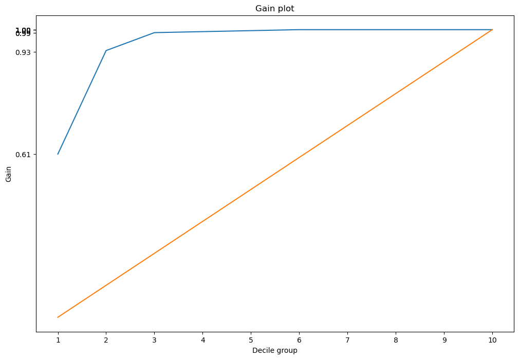

```python
fig, ax = plt.subplots(figsize = (12,8))
sns.lineplot(data = lift_gain_report, x = lift_gain_report['Decile group'], y = lift_gain_report['Gain'])
sns.lineplot(data = lift_gain_report, x = lift_gain_report['Decile group'], y = lift_gain_report['Random Selection'])
plt.title('Gain plot')
plt.xticks(lift_gain_report['Decile group'])
plt.yticks(round(lift_gain_report['Gain'],2))

plt.show()
```

## 5. Feature importance

### 5.1 Feature importance analysis

```python
feat_imp = model.get_booster().get_score(importance_type = 'total_gain')
```

```python
feat_imp
```

```
{'Customer_Age': 1248.474853515625,
 'Dependent_count': 153.51998901367188,
 'Total_Relationship_Count': 1835.7877197265625,
 'Months_Inactive_12_mon': 772.5855712890625,
 'Contacts_Count_12_mon': 912.7930908203125,
 'Credit_Limit': 1175.3634033203125,
 'Total_Used_Bal': 2368.373046875,
 'Total_Amt_Chng_Q4_Q1': 2187.464599609375,
 'Total_Trans_Amt': 6820.0400390625,
 'Total_Ct_Chng_Q4_Q1': 3286.389892578125,
 'Avg_Utilization_Ratio': 1491.2467041015625,
 'Gender_F': 139.56570434570312,
 'Gender_M': 117.20911407470703,
 'Education_Level_College': 18.767253875732422,
 'Education_Level_Graduate': 31.163938522338867,
 'Education_Level_High School': 17.438222885131836,
 'Education_Level_Post-Graduate / Doctorate': 20.08355712890625,
 'Education_Level_Uneducated': 17.159809112548828,
 'Education_Level_Unknown': 16.987314224243164,
 'Income_Category_$120K +': 22.07001304626465,
 'Income_Category_$40K - $60K': 31.773822784423828,
 'Income_Category_$60K - $80K': 38.12078857421875,
 'Income_Category_$80K - $120K': 46.569664001464844,
 'Income_Category_Less than $40K': 32.875125885009766,
 'Income_Category_Unknown': 17.536678314208984}
```

```python
feature_importance = pd.DataFrame()
feature_importance['Variable'] = feat_imp.keys()
feature_importance['Importance value'] = feat_imp.values()
feature_importance['% Importance value'] = feature_importance['Importance value'] / feature_importance['Importance value'].sum()*100
feature_importance.sort_values(by = ['Importance value'], ascending = False)
```

|  | Variable | Importance value | % Importance value |
| --- | --- | --- | --- |
| 8 | Total_Trans_Amt | 6820.040039 | 29.887079 |
| 9 | Total_Ct_Chng_Q4_Q1 | 3286.389893 | 14.401762 |
| 6 | Total_Used_Bal | 2368.373047 | 10.378788 |
| 7 | Total_Amt_Chng_Q4_Q1 | 2187.464600 | 9.586003 |
| 2 | Total_Relationship_Count | 1835.787720 | 8.044869 |
| 10 | Avg_Utilization_Ratio | 1491.246704 | 6.535007 |
| 0 | Customer_Age | 1248.474854 | 5.471121 |
| 5 | Credit_Limit | 1175.363403 | 5.150729 |
| 4 | Contacts_Count_12_mon | 912.793091 | 4.000082 |
| 3 | Months_Inactive_12_mon | 772.585571 | 3.385658 |
| 1 | Dependent_count | 153.519989 | 0.672762 |
| 11 | Gender_F | 139.565704 | 0.611611 |
| 12 | Gender_M | 117.209114 | 0.513639 |
| 22 | Income_Category_$80K - $120K | 46.569664 | 0.204080 |
| 21 | Income_Category_$60K - $80K | 38.120789 | 0.167055 |
| 23 | Income_Category_Less than $40K | 32.875126 | 0.144067 |
| 20 | Income_Category_$40K - $60K | 31.773823 | 0.139241 |
| 14 | Education_Level_Graduate | 31.163939 | 0.136568 |
| 19 | Income_Category_$120K + | 22.070013 | 0.096716 |
| 16 | Education_Level_Post-Graduate / Doctorate | 20.083557 | 0.088011 |
| 13 | Education_Level_College | 18.767254 | 0.082243 |
| 24 | Income_Category_Unknown | 17.536678 | 0.076850 |
| 15 | Education_Level_High School | 17.438223 | 0.076419 |
| 17 | Education_Level_Uneducated | 17.159809 | 0.075198 |
| 18 | Education_Level_Unknown | 16.987314 | 0.074443 |

#### Comments:

#### 1) Total_Trans_Amt ( Total amount of payments made in last 12 months ) has an importance of 29,89% for our model.

#### 2) Total_Ct_Chng_Q4_Q1 ( Change in number of payments (Q4 over Q1) ) has an importance of 14,4% for our model.

#### 3) Total_Used_Bal ( Total used amount from credit card limit ) ) has an importance of 10,38% for our model.

#### 4) Total_Amt_Chng_Q4_Q1 ( Change in transaction amount (Q4 over Q1) ) has an importance of 9,59% for our model.

#### 5) Total_Relationship_Count ( Number of products in portfolio ) has an importance of 8,04% for our model.

#### 6) Avg_Utilization_Ratio ( Average utilization ratio per month (Total spend out of Credit limit) ) has an importance of 6,54% for our model.

#### 7) Customer_Age has an importance of 5,47% for our model.

#### 8) Credit_Limit has an importance of 5,15% for our model.

#### 9) Contacts_Count_12_mon ( Number of contacts/interactions with the bank in the last 12 months ) has an importance of 4% for our model.

#### 10) Months_Inactive_12_mon has an importance of 3,39% for our model.

### 5.2 Shap chart

```python
explainer = shap.TreeExplainer(model)
shap_values = explainer.shap_values(X_test)
```

```
ntree_limit is deprecated, use `iteration_range` or model slicing instead.
```

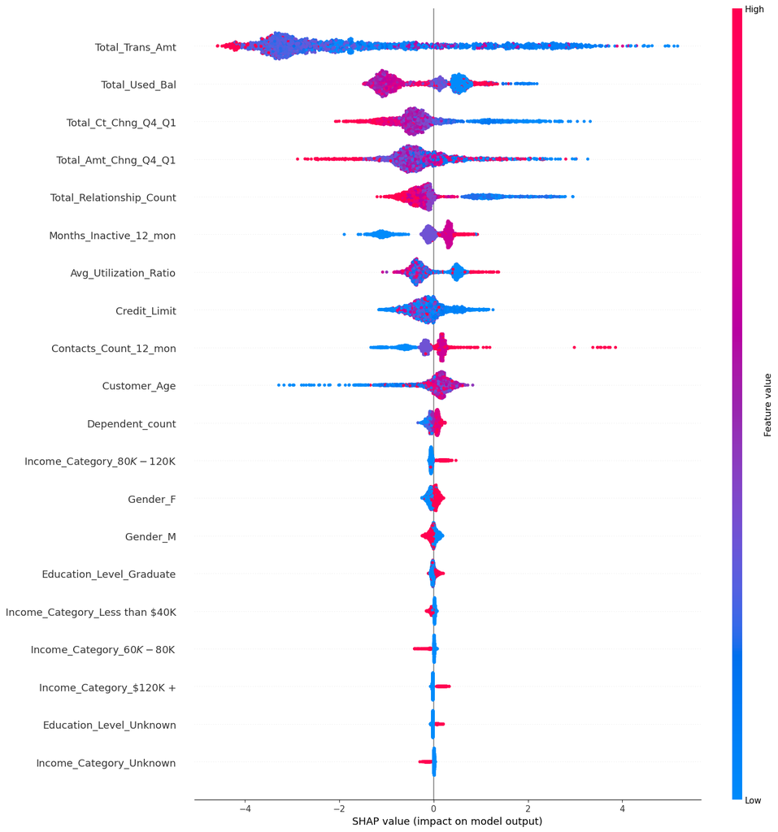

```python
shap.summary_plot(shap_values, X_test, plot_size = (15,15))
```

#### Comments:

#### 1) Total_Trans_Amt: Probability for a client to churn is higher if there are less payments made in 12 months.

#### 2) Total_Used_Bal: Probability for a client to churn is higher if the total amount of used balance from credit card is lower.

#### 3) Total_Ct_Chng_Q4_Q1: Probability for a client to churn is higher if the change in number of payments is lower. For the client not tu churn, he needs to have more payments made.

#### 4) Total_Amt_Chng_Q4_Q1: Probability for a client to churn is higher if the change in transaction amount is moderate. For the client not to churn, he needs to have a bigger change in transaction amount.

#### 5) Total_Relationship_Count: Probability for a client to churn is higher if the client has less products in portfolio.

- SHAP observation for client 1010

```python
index = 1010
shap.initjs()
shap.force_plot(explainer.expected_value, shap_values[index], X_test.iloc[index], link = 'logit')
```

[output not shown]